# Graduate Admissions: Predictive Modeling and Statistical Analysis

202330420212 - Sihan Chen

2025-06-17

# 1 Introduction

In the post-pandemic era, graduate admission has become a key decision point for many students. This project analyzes factors influencing admission probability based on GRE, TOEFL, CGPA, and research experience.

We aim to answer:

1. What are the correlations between each variable?
2. Can admission probability be accurately predicted?
3. Which 3 variables correlate most strongly with admission chances?
4. How does research experience affect admission rates?

We use linear regression and Lasso regression to model the relationship. The model can be described mathematically as:

$$\hat{y} = \beta_0 + \beta_1 x_1 + \beta_2 x_2 + \dots + \beta_n x_n +
\epsilon$$

Where $\hat{y}$ is the predicted admission chance and $x_i$ are features like GRE, GPA, etc.

# 2 Data Loading & Preparation

```r
library(tidyverse)
library(corrplot)
library(caret)
library(glmnet)
library(ggplot2)
library(gridExtra)
library(reshape2)
```

```r
train <- read.csv("Admission_Predict.csv")
test <- read.csv("Admission_Predict_Ver1.1.csv")

clean_names <- function(df) {
  df <- df %>% rename_with(~gsub("\\s+|\\.", "", .), everything())
  df <- df %>% rename(LOR = LOR)
  df$Research <- as.factor(df$Research)
  return(df)
}

train <- clean_names(train)
test <- clean_names(test)

str(train)
```

```
## 'data.frame':    400 obs. of  9 variables:
##  $ SerialNo        : int  1 2 3 4 5 6 7 8 9 10 ...
##  $ GREScore        : int  337 324 316 322 314 330 321 308 302 323 ...
##  $ TOEFLScore      : int  118 107 104 110 103 115 109 101 102 108 ...
##  $ UniversityRating: int  4 4 3 3 2 5 3 2 1 3 ...
##  $ SOP             : num  4.5 4 3 3.5 2 4.5 3 3 2 3.5 ...
##  $ LOR             : num  4.5 4.5 3.5 2.5 3 3 4 4 1.5 3 ...
##  $ CGPA            : num  9.65 8.87 8 8.67 8.21 9.34 8.2 7.9 8 8.6 ...
##  $ Research        : Factor w/ 2 levels "0","1": 2 2 2 2 1 2 2 1 1 1 ...
##  $ ChanceofAdmit   : num  0.92 0.76 0.72 0.8 0.65 0.9 0.75 0.68 0.5 0.45 ...
```

# 3 Exploratory Data Analysis (EDA)

## 3.1 Summary & Distributions

```r
summary(train)
```

```
##     SerialNo        GREScore       TOEFLScore    UniversityRating      SOP
##  Min.   :  1.0   Min.   :290.0   Min.   : 92.0   Min.   :1.000    Min.   :1.0
##  1st Qu.:100.8   1st Qu.:308.0   1st Qu.:103.0   1st Qu.:2.000    1st Qu.:2.5
##  Median :200.5   Median :317.0   Median :107.0   Median :3.000    Median :3.5
##  Mean   :200.5   Mean   :316.8   Mean   :107.4   Mean   :3.087    Mean   :3.4
##  3rd Qu.:300.2   3rd Qu.:325.0   3rd Qu.:112.0   3rd Qu.:4.000    3rd Qu.:4.0
##  Max.   :400.0   Max.   :340.0   Max.   :120.0   Max.   :5.000    Max.   :5.0
##       LOR             CGPA       Research ChanceofAdmit
##  Min.   :1.000   Min.   :6.800   0:181    Min.   :0.3400
##  1st Qu.:3.000   1st Qu.:8.170   1:219    1st Qu.:0.6400
##  Median :3.500   Median :8.610            Median :0.7300
##  Mean   :3.453   Mean   :8.599            Mean   :0.7244
##  3rd Qu.:4.000   3rd Qu.:9.062            3rd Qu.:0.8300
##  Max.   :5.000   Max.   :9.920            Max.   :0.9700
```

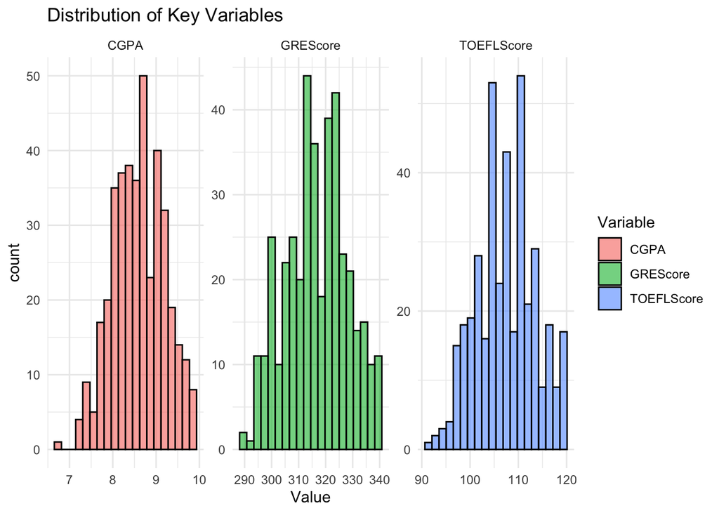

```r
train %>%
  select(GREScore, TOEFLScore, CGPA) %>%
  gather(key = "Variable", value = "Value") %>%
  ggplot(aes(x = Value, fill = Variable)) +
  geom_histogram(color = "black", bins = 20, alpha = 0.6) +
  facet_wrap(~ Variable, scales = "free") +
  theme_minimal() + labs(title = "Distribution of Key Variables")
```

## 3.2 Correlation Matrix (Q1)

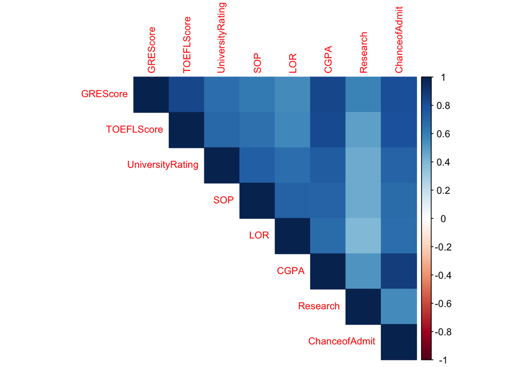

```r
cor_matrix <- cor(train[,-1] %>% mutate_if(is.factor, as.numeric))
corrplot(cor_matrix, method = "color", type = "upper", tl.cex = 0.8)
```

```r
round(sort(cor_matrix["ChanceofAdmit",], decreasing = TRUE), 3)
```

```
##    ChanceofAdmit             CGPA         GREScore       TOEFLScore
##            1.000            0.873            0.803            0.792
## UniversityRating              SOP              LOR         Research
##            0.711            0.676            0.670            0.553
```

**Analysis**: We observe that CGPA has the strongest correlation with admission chance (0.87), followed by GRE (0.80) and TOEFL (0.79). SOP and LOR have moderate correlation, while Research is weaker but still positive.

# 4 Visual Insights (Q3)

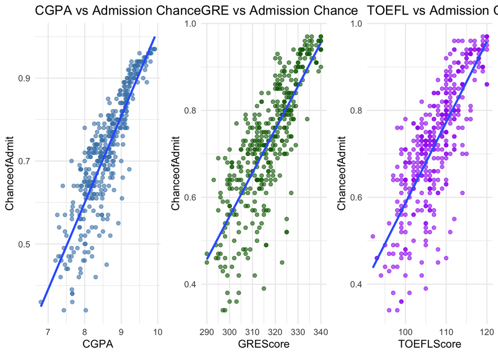

```r
p1 <- ggplot(train, aes(CGPA, ChanceofAdmit)) +
  geom_point(color = "steelblue", alpha=0.6) + geom_smooth(method = "lm", se=FALSE) +
  theme_minimal() + labs(title = "CGPA vs Admission Chance")

p2 <- ggplot(train, aes(GREScore, ChanceofAdmit)) +
  geom_point(color = "darkgreen", alpha=0.6) + geom_smooth(method = "lm", se=FALSE) +
  theme_minimal() + labs(title = "GRE vs Admission Chance")

p3 <- ggplot(train, aes(TOEFLScore, ChanceofAdmit)) +
  geom_point(color = "purple", alpha=0.6) + geom_smooth(method = "lm", se=FALSE) +
  theme_minimal() + labs(title = "TOEFL vs Admission Chance")

grid.arrange(p1, p2, p3, ncol = 3)
```

**Analysis**: All three variables exhibit strong linear patterns with admission chance, confirming their predictive value. Especially, CGPA demonstrates a tightly clustered upward trend.